# Data Exploration Using R and Spark

#### I gonna use R and Spark for a sample data exploration task to explore the R capabilites for using spark distributed data processing

**Setup**

There is almost no installations needed for this tutorial but here is the requried tools for running this script in your machine.

- Java and i assumed it was already installed on your machine and why java and the answer is very simple ( SPARK written in Scala which is a JMV **Java Virtual Machine** language ) you can download java from [here](https://java.com/en/download/) and this link will help you
- Spark lastest version 2.2 binaries and you can download it from [here](https://spark.apache.org/downloads.html) and follow the setup instruction if you don’t no worries i will do this step for you ;)
- R version 3
- R Studio to write this notebook
- ggplot2 for graphs

```r
# checking if the Spark Home is declared as an enviroment variable by
# checking the existence of the SPARK_HOME Path variable and if not exist
# don't worry i will do it for you

if (nchar(Sys.getenv("SPARK_HOME")) < 1) {

    # download.file(url =
    # 'https://d3kbcqa49mib13.cloudfront.net/spark-2.2.0-bin-hadoop2.7.tgz',
    # destfile = 'spark-2.2.0-bin-hadoop2.7.tgz')
    # untar('spark-2.2.0-bin-hadoop2.7.tgz')
    Sys.setenv(SPARK_HOME = paste0(getwd(), "/spark-2.2.0-bin-hadoop2.7"))
}
```

**- SparkR is an R package that provides a light-weight frontend to use Apache Spark from R. In Spark 2.2.0, SparkR provides a distributed data frame implementation that supports operations like selection, filtering, aggregation etc. (similar to R data frames, dplyr) but on large datasets. SparkR also supports distributed machine learning using MLlib.**

**- The entry point into SparkR is the SparkSession which connects your R program to a Spark cluster. You can create a SparkSession using sparkR.session and pass in options such as the application name, any spark packages depended on.**

```r
library(ggplot2)
library(dplyr)
## importing the SparkR library
library(SparkR, lib.loc = c(normalizePath(file.path(Sys.getenv("SPARK_HOME"),
    "R", "lib"))))
## create
sparkR.session(master = "local[*]", sparkConfig = list(spark.driver.memory = "2g"))
```

```
Spark package found in SPARK_HOME: /home/mokhtar/Desktop/data_exploration_R_Spark/spark-2.2.0-bin-hadoop2.7
```

### Creating SparkDataFrames

With a SparkSession, applications can create SparkDataFrames from

- Local R data frame for example **“df <- as.DataFrame(faithful)”**.
- Hive table for example **“results <- sql(‘FROM src SELECT key, value’)”**.
- Other data sources and that is our case reading data from CSV file.

The following dataset represent the flights in 2015 for x airlines so my first step is to read the dataset i will depend on my analysis on Q/A style by asking some questions and trying to answer them by a simple graph

```r
csvPath <- "data/flight-data/csv/2015-summary.csv"
df <- read.df(csvPath, "csv", header = "true", inferSchema = "true", na.strings = "NA")
head(df)
```

| DEST_COUNTRY_NAME | ORIGIN_COUNTRY_NAME | count |
| --- | --- | --- |
| United States | Romania | 15 |
| United States | Croatia | 1 |
| United States | Ireland | 344 |
| Egypt | United States | 15 |
| United States | India | 62 |
| United States | Singapore | 1 |

**What is the top 10 country that people like to travel most?**

```r
new_df <- summarize(groupBy(df, df$DEST_COUNTRY_NAME), count = sum(df$count))
head(new_df)
```

| DEST_COUNTRY_NAME | count |
| --- | --- |
| Anguilla | 41 |
| Russia | 176 |
| Paraguay | 60 |
| Senegal | 40 |
| Sweden | 118 |
| Kiribati | 26 |

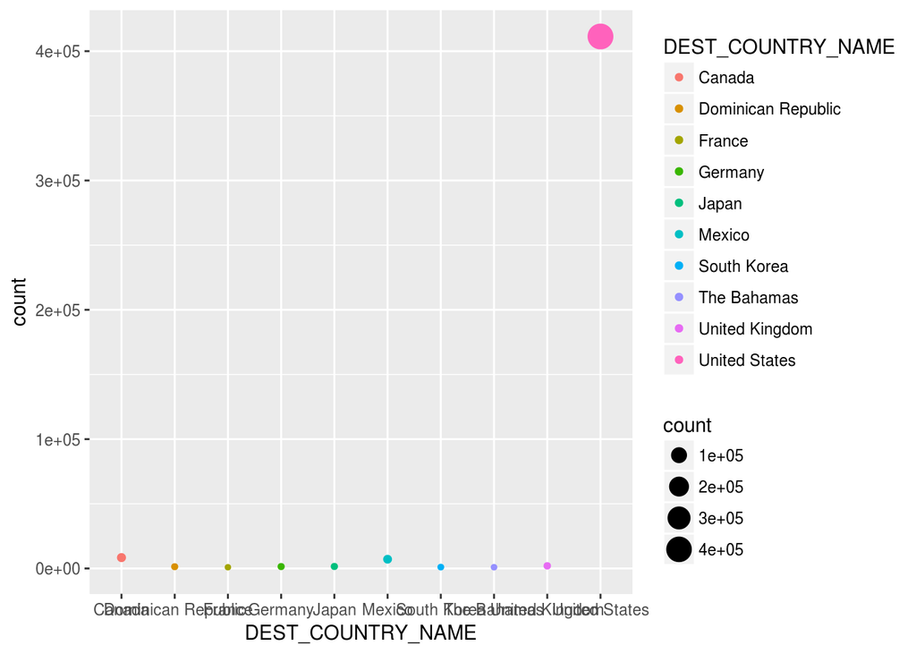

```r
plot_df <- as.data.frame(new_df) %>% dplyr::arrange(desc(count))
View(plot_df)
plot_df$DEST_COUNTRY_NAME <- factor(plot_df$DEST_COUNTRY_NAME)

p <- ggplot(plot_df[1:10,], aes(DEST_COUNTRY_NAME, count))
p + geom_point(aes(colour = DEST_COUNTRY_NAME, size = count))
```

**What is the top 10 country that people hate to travel most?**

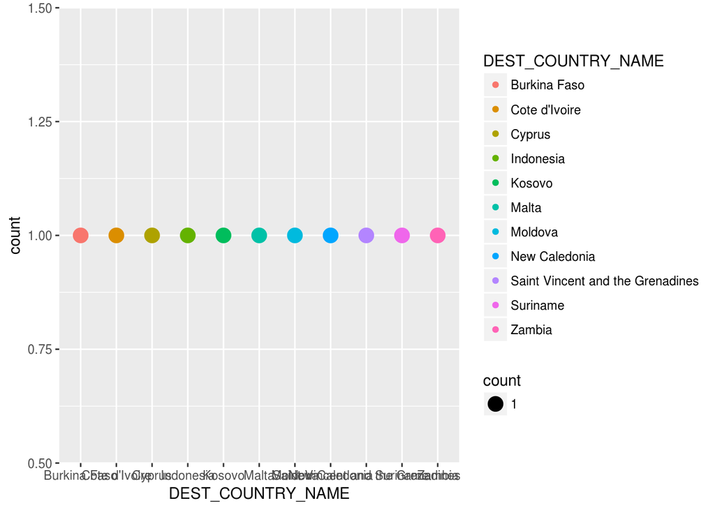

```r
plot_df$DEST_COUNTRY_NAME <- factor(plot_df$DEST_COUNTRY_NAME)
n <- nrow(plot_df)
p <- ggplot(plot_df[(n-10):n,], aes(DEST_COUNTRY_NAME, count))
p + geom_point(aes(colour = DEST_COUNTRY_NAME, size = count))
```

**What is the top 10 country that people like to leave most?**

```r
new_df <- summarize(groupBy(df, df$ORIGIN_COUNTRY_NAME), count = sum(df$count))
head(new_df)
```

| ORIGIN_COUNTRY_NAME | count |
| --- | --- |
| Paraguay | 6 |
| Russia | 161 |
| Anguilla | 38 |
| Senegal | 42 |
| Sweden | 119 |
| Kiribati | 35 |

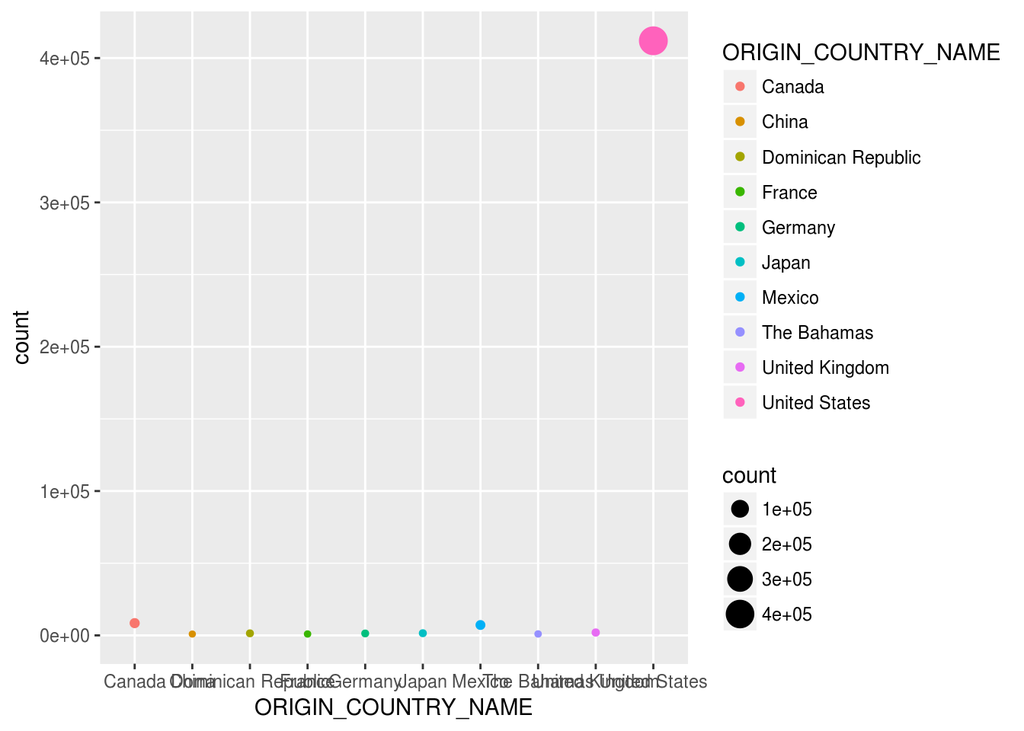

```r
plot_df <- as.data.frame(new_df) %>% dplyr::arrange(desc(count))
View(plot_df)
plot_df$ORIGIN_COUNTRY_NAME <- factor(plot_df$ORIGIN_COUNTRY_NAME)

p <- ggplot(plot_df[1:10,], aes(ORIGIN_COUNTRY_NAME, count))
p + geom_point(aes(colour = ORIGIN_COUNTRY_NAME, size = count))
```

**What is the top 10 country that people hate to leave most?**

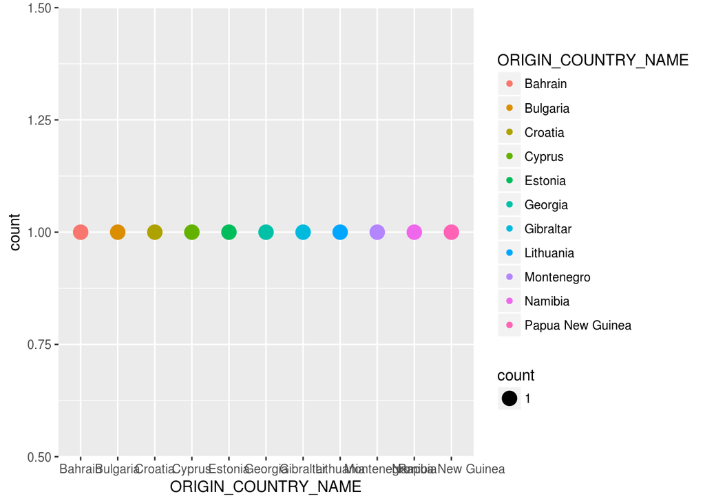

```r
plot_df$ORIGIN_COUNTRY_NAME <- factor(plot_df$ORIGIN_COUNTRY_NAME)
n <- nrow(plot_df)
p <- ggplot(plot_df[(n-10):n,], aes(ORIGIN_COUNTRY_NAME, count))
p + geom_point(aes(colour = ORIGIN_COUNTRY_NAME, size = count))
```

**What is the top 10 country that people like to travel to U.S ?**

```r
usa_flights_rdd <- filter(df, df$DEST_COUNTRY_NAME == "United States")

new_df <- summarize(groupBy(usa_flights_rdd, df$ORIGIN_COUNTRY_NAME), count = sum(df$count))
head(new_df)
```

| ORIGIN_COUNTRY_NAME | count |
| --- | --- |
| Paraguay | 6 |
| Russia | 161 |
| Anguilla | 38 |
| Senegal | 42 |
| Sweden | 119 |
| Kiribati | 35 |

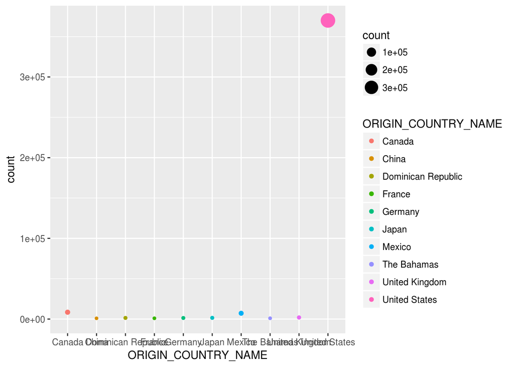

```r
plot_df <- as.data.frame(new_df) %>% dplyr::arrange(desc(count))
View(plot_df)
plot_df$ORIGIN_COUNTRY_NAME <- factor(plot_df$ORIGIN_COUNTRY_NAME)

p <- ggplot(plot_df[1:10,], aes(ORIGIN_COUNTRY_NAME, count))
p + geom_point(aes(colour = ORIGIN_COUNTRY_NAME, size = count))
```

**What is the top 10 country that people hate to travel to U.S ?**

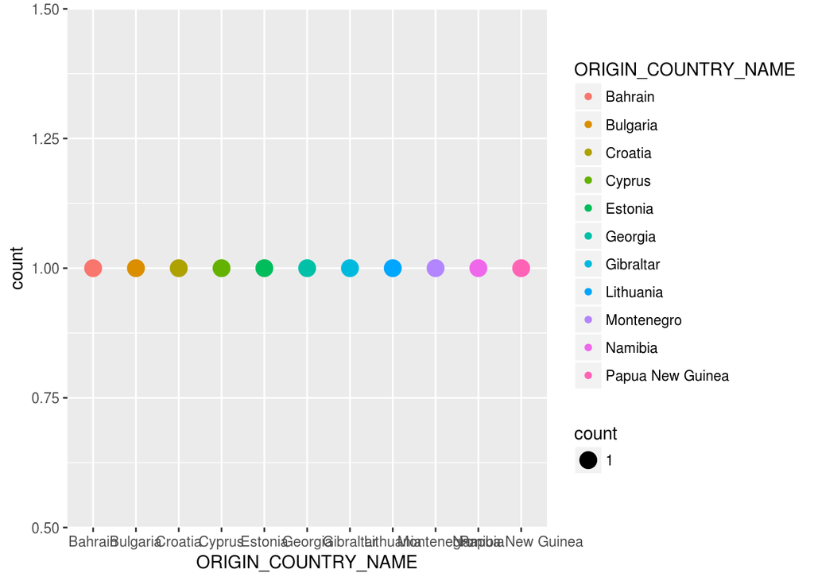

```r
plot_df$ORIGIN_COUNTRY_NAME <- factor(plot_df$ORIGIN_COUNTRY_NAME)
n <- nrow(plot_df)
p <- ggplot(plot_df[(n-10):n,], aes(ORIGIN_COUNTRY_NAME, count))
p + geom_point(aes(colour = ORIGIN_COUNTRY_NAME, size = count))
```

### References

- [SparkR Tutorials](https://spark.apache.org/docs/latest/sparkr.html)